# stat_proy

Proyecto final Javier Vega EDS.

Introducción

Dentro de la red de servicios para clientes móviles, tanto de datos como voz (2G,3G,4G,5G), se manejan estadísticas para determinar la calidad del servicio prestado. En este contexto, el indicador de preferencia es el llamado “uptime”, que hace referencia a la cantidad de tiempo que los elementos de red se encuentran disponibles y entregando el servicio. Así, un elemento que se encuentra siempre disponible tiene un 100% de uptime y en caso de fallar, se pondera el tiempo de indisponibilidad para recalcular el indicador. Dichos registros son obtenidos para cada hardware de red y guardados con granularidad diaria en una base de datos administrada por supervisión de redes. Este estudio busca determinar el nivel de impacto que tienen los sistemas frontales en el indicador de uptime red la región metropolitana y por consecuencia, cuanto deterioran la calidad del servicio brindado a los clientes. Se utilizará un analisis cuantitativo-descriptivo basado en datos, tratando de establecer correlacion entre las variables complementando con análisis exploratorios visuales para evaluar tendencias y relaciones. Dada las características del set, se podrán realizar análisis por zona geográfica, fecha y clúster operativo. Hipótesis: Los sistemas frontales que afectan a la región metropolitana provocan una baja en el indicador de uptime de red. Fuentes de datos: BBDD_Uptime_Red, Dirección Meteorológica de Chile - Servicios Climáticos (https://climatologia.meteochile.gob.cl/application/requerimiento/producto/RE1006), Estación Eulogio Sánchez, Tobalaba Ad. Para efectos de privacidad, se modificarán los nombres de emplazamiento, celdas, sitio, clúster y agencia.

Ideas previas:

Antes de comenzar con el análisis, la presunción de que el indicador de uptime se deteriora con los eventos fluviales nace de la premisa de que este tipo de eventos causa deterioro no solo de los propios elementos sino también de las condiciones necesarias de operación, tales como la energía eléctrica, líneas vista de enlaces microonda, entre otros. Por otra parte, la capacidad de gestión y resolución de incidencias se relentiza afectando los tiempo de respuesta y la pronta recuperación de los servicios. Dadas estas presmisas, se espera que el indicador sea deteriorado en un porcentaje importante a medida que los eventos de lluvia sean de mayor intensidad y duración.

```python
import pandas as pd
import matplotlib.pylab as plt
%matplotlib inline
```

Para el desarrollo de la hipotesis, se consolidaron los datos de lluvias registrados por la Dirección Meteorológica de Chile - Servicios Climáticos (https://climatologia.meteochile.gob.cl/application/requerimiento/producto/RE1006) desde mayo hasta el 17 de julio de 2022, con una granularidad de días, con los datos de uptime de red para cada elemento en el mismo período, también con peridiocidad diaria, resultando el siguiente data set:

```python
ds = pd.read_excel("C:/Users/jvegaga/Desktop/Tarea_U/Estadistica/dataset_javiervega.xlsx")
```

```python
ds.head(10)
ds
```

|  | fecha | semana | region | comuna_cod | cluster_cod | sitio_cod | data_lluvia | availability |
| --- | --- | --- | --- | --- | --- | --- | --- | --- |
| 0 | 2022-05-01 | 17 | 13 | xvyr6 01!6. | uy | us08N | 0.0 | 100 |
| 1 | 2022-05-01 | 17 | 13 | 3.uD!y1 0u | uy | 208!9 | 0.0 | 100 |
| 2 | 2022-05-01 | 17 | 13 | u.1t6.8y | u1x | 20s!7 | 0.0 | 14 |
| 3 | 2022-05-01 | 17 | 13 | 3.D93yv6 . | uuy | xru8N | 0.0 | 100 |
| 4 | 2022-05-01 | 17 | 13 | u.1t6.8y | u1x | u.1ty | 0.0 | 100 |
| ... | ... | ... | ... | ... | ... | ... | ... | ... |
| 685677 | 2022-07-17 | 28 | 13 | 3.uD!y1 0u | uy | ?03uL | 0.0 | 100 |
| 685678 | 2022-07-17 | 28 | 13 | 3.D93yv6 . | uuy | 2.xr0 | 0.0 | 100 |
| 685679 | 2022-07-17 | 28 | 13 | 3.uD!y1 0u | uy | ?03uL | 0.0 | 100 |
| 685680 | 2022-07-17 | 28 | 13 | 3.D93yv6 . | uuy | 2.xr0 | 0.0 | 100 |
| 685681 | 2022-07-17 | 28 | 13 | 3.D93yv6 . | uuy | 2.xr0 | 0.0 | 100 |

685682 rows × 8 columns

El dataframe contiene datos de registro de uptime diario para cada sitio (elemento de red o equipo), en donde podemos ver diferentes valores dependiendo de la fecha y del elemento, con la respectiva cantidad de lluvia registrada en la RM para cada día en particular. En concreto, queremos buscar si existe algún tipo de relación entre la lluvia caída y cambios en los valores uptime. Para esto, primero examinaremos como se comporta dentro del dataframe el indicador de uptime.

```python
ds.availability.describe()
```

```
count    685682.000000
mean         94.880229
std          20.243906
min           0.000000
25%         100.000000
50%         100.000000
75%         100.000000
max         100.000000
Name: availability, dtype: float64
```

Podemos apreciar,como primera mirada, que en términos de cuartil más del 75% de los registros rondan el 100%, lo cual hace sentido por cuanto los valores normales de uptime promedio rondan el 95% o más, lo podemos apreciar también en el promedio, con 94.88 puntos. Esto nos indica que los valores bajo 100 se encuentran en el primer cuartil, lo cual comprobaremos.

```python
ds[ds['availability'].between(0.001,99)]
```

|  | fecha | semana | region | comuna_cod | cluster_cod | sitio_cod | data_lluvia | availability |
| --- | --- | --- | --- | --- | --- | --- | --- | --- |
| 2 | 2022-05-01 | 17 | 13 | u.1t6.8y | u1x | 20s!7 | 0.0 | 14 |
| 38 | 2022-05-01 | 17 | 13 | 3.2x. | u1x | .8s3. | 0.0 | 99 |
| 61 | 2022-05-01 | 17 | 13 | 3.Dx61t.1. | uu | 3y?3. | 0.0 | 83 |
| 68 | 2022-05-01 | 17 | 13 | u.1t6.8y | u1x | 1tus9 | 0.0 | 25 |
| 72 | 2022-05-01 | 17 | 13 | !y361. | u1x | .!719 | 0.0 | 99 |
| ... | ... | ... | ... | ... | ... | ... | ... | ... |
| 685555 | 2022-07-17 | 28 | 13 | 3.2x. | u1x | .8s3. | 0.0 | 99 |
| 685570 | 2022-07-17 | 28 | 13 | ws636!sv. | u1x | !.!y1 | 0.0 | 99 |
| 685571 | 2022-07-17 | 28 | 13 | ws636!sv. | u1x | 2.ws6 | 0.0 | 99 |
| 685649 | 2022-07-17 | 28 | 13 | xs01t0D.3ty | uuy | r6ñ!3 | 0.0 | 42 |
| 685669 | 2022-07-17 | 28 | 13 | v01!. | u1x | 02?.N | 0.0 | 98 |

79793 rows × 8 columns

Como vemos, tan solo un 11,6% de los valores del dataset tienen valores distintos de 100. Caso contrario con los valores de uptime, los registros de lluvia son mucho más escasos y pareados con cada sitio por día y representan el 21,7% del total del data set, por lo que en términos de resumen vemos la mayoría de los datos fuera de los primeros tres cuartiles, con un promedio de los registros de 1.2mm de agua caída y un máximo de 24mm de agua caída. Como se muestra a continuación:

```python
ds.data_lluvia.describe()
```

```
count    685682.000000
mean          1.234561
std           3.949334
min           0.000000
25%           0.000000
50%           0.000000
75%           0.000000
max          24.000000
Name: data_lluvia, dtype: float64
```

```python
ds[ds['data_lluvia'].between(0.001,100)]
```

|  | fecha | semana | region | comuna_cod | cluster_cod | sitio_cod | data_lluvia | availability |
| --- | --- | --- | --- | --- | --- | --- | --- | --- |
| 272566 | 2022-06-01 | 22 | 13 | x6vws0 | uuy | v.2y1 | 3.3 | 100 |
| 272567 | 2022-06-01 | 22 | 13 | x. v0D7svt. y | uux | 2x01y | 3.3 | 100 |
| 272568 | 2022-06-01 | 22 | 13 | 3.uD!y1 0u | uy | 383.9 | 3.3 | 99 |
| 272569 | 2022-06-01 | 22 | 13 | 3.uD!y1 0u | uy | 0 6v9 | 3.3 | 100 |
| 272570 | 2022-06-01 | 22 | 13 | xvyr6 01!6. | uy | 68yv | 3.3 | 99 |
| ... | ... | ... | ... | ... | ... | ... | ... | ... |
| 668101 | 2022-07-15 | 28 | 13 | 3.uD!y1 0u | uy | ?03uL | 0.1 | 100 |
| 668102 | 2022-07-15 | 28 | 13 | 3.D93yv6 . | uuy | 2.xr0 | 0.1 | 100 |
| 668103 | 2022-07-15 | 28 | 13 | 3.D93yv6 . | uuy | 2.xr0 | 0.1 | 100 |
| 668104 | 2022-07-15 | 28 | 13 | 3.D93yv6 . | uuy | 2.xr0 | 0.1 | 100 |
| 668105 | 2022-07-15 | 28 | 13 | 3.uD!y1 0u | uy | ?03uL | 0.1 | 100 |

149437 rows × 8 columns

A continuación revisaremos si existe una correlación directa entre ambos factores que nos permita obtener conclusiones de cara a nuestra hipótesis.

```python
ds[['data_lluvia','availability']].corr()
```

|  | data_lluvia | availability |
| --- | --- | --- |
| data_lluvia | 1.000000 | 0.002559 |
| availability | 0.002559 | 1.000000 |

Tal podemos ver entonces, que la correlación entre ambos valores es más bien baja o nula con un valor de 0.00255. Esto sin embargo no nos permite ser concluyentes respecto de la hipótesis, principalmente porque este valor de correlación está aplicado a todos los registros del dataset, que como vimos, son tanto en proporción como en catidad de registros muy dispares. Es por esto que continuaremos el análisis estableciendo relaciones temporales entre ambas variables (por semana en primera instancia), de esta forma podemos ver su comportamiento y respuesta en los momentos de interacción de los eventos.

```python
ds2= ds.groupby(['semana']).mean()
ds2
```

| semana | region | data_lluvia | availability |
| --- | --- | --- | --- |
| 17 | 13.0 | 0.000000 | 92.210999 |
| 18 | 13.0 | 0.000000 | 92.763220 |
| 19 | 13.0 | 0.000000 | 94.322846 |
| 20 | 13.0 | 0.000000 | 94.839219 |
| 21 | 13.0 | 0.000000 | 95.135561 |
| 22 | 13.0 | 1.457247 | 95.337681 |
| 23 | 13.0 | 0.000000 | 95.574092 |
| 24 | 13.0 | 0.000000 | 95.968615 |
| 25 | 13.0 | 1.614286 | 95.864136 |
| 26 | 13.0 | 2.671429 | 95.072225 |
| 27 | 13.0 | 5.542857 | 94.862277 |
| 28 | 13.0 | 2.472023 | 94.326622 |

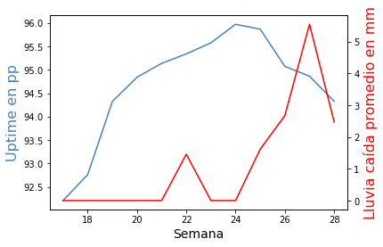

```python
col1 = 'steelblue'
col2 = 'red'

fig,ax = plt.subplots()

ax.plot(ds2.index, ds2.availability, color=col1)

ax.set_xlabel('Semana', fontsize=14)

ax.set_ylabel('Uptime en pp', color=col1, fontsize=16)

ax2 = ax.twinx()

ax2.plot(ds2.index, ds2.data_lluvia, color=col2)

ax2.set_ylabel('Lluvia caída promedio en mm', color=col2, fontsize=16)
```

Al graficar ambas variables, podemos ver como claramente desde la semana 25 en adelante, en donde los eventos de lluvia comienzan a hacerce cada vez más frecuentes e importantes en términos de agua caída, el uptime de red comienza a caer en al menos 1 punto en las 3 semanas siguientes. Importante destacar la gradualidad de la caída de uptime que se observa va a la par con el alza del agua caída promedio en las semanas venideras. Otro evento importante se observa en la semana 22, en donde la cantidad de agua caída está entre los 1 y 2 mm promedio para la regíon pero en términos de uptime no parece afectar el desempeño. Esto nos permite inferir que hay una relación entre la duración de los eventos de lluvia y el deterioro del uptime, por tanto mientras más se desarrolle el evento en el tiempo, mayor impacto tendrá en el indicador. Para finalizar, veremos el impacto por zona, para observar diferencias en la afectación del indicador dependiendo el área geografica.

```python
ds3= pd.pivot_table(ds, index='semana',columns='cluster_cod')
ds3
```

| cluster_cod semana | availability u1x | availability uu | availability uux | availability uuy | availability uy | data_lluvia u1x | data_lluvia uu | data_lluvia uux | data_lluvia uuy | data_lluvia uy | region u1x | region uu | region uux | region uuy | region uy |
| --- | --- | --- | --- | --- | --- | --- | --- | --- | --- | --- | --- | --- | --- | --- | --- |
| 17 | 90.728814 | 82.721435 | 89.982790 | 96.853415 | 96.471206 | 0.000000 | 0.000000 | 0.000000 | 0.000000 | 0.000000 | 13 | 13 | 13 | 13 | 13 |
| 18 | 93.603876 | 85.747336 | 88.689613 | 94.294595 | 96.729819 | 0.000000 | 0.000000 | 0.000000 | 0.000000 | 0.000000 | 13 | 13 | 13 | 13 | 13 |
| 19 | 95.287688 | 88.755257 | 92.835956 | 94.855937 | 96.434751 | 0.000000 | 0.000000 | 0.000000 | 0.000000 | 0.000000 | 13 | 13 | 13 | 13 | 13 |
| 20 | 96.219506 | 89.847375 | 91.777758 | 96.917882 | 96.563857 | 0.000000 | 0.000000 | 0.000000 | 0.000000 | 0.000000 | 13 | 13 | 13 | 13 | 13 |
| 21 | 96.499809 | 92.121286 | 90.492484 | 97.338230 | 97.001336 | 0.000000 | 0.000000 | 0.000000 | 0.000000 | 0.000000 | 13 | 13 | 13 | 13 | 13 |
| 22 | 96.346893 | 91.357753 | 92.744352 | 96.496327 | 97.139887 | 1.457143 | 1.457143 | 1.457143 | 1.457143 | 1.457500 | 13 | 13 | 13 | 13 | 13 |
| 23 | 96.952572 | 89.706010 | 93.234022 | 96.506523 | 97.779938 | 0.000000 | 0.000000 | 0.000000 | 0.000000 | 0.000000 | 13 | 13 | 13 | 13 | 13 |
| 24 | 97.487268 | 91.830009 | 92.425846 | 96.925337 | 98.101618 | 0.000000 | 0.000000 | 0.000000 | 0.000000 | 0.000000 | 13 | 13 | 13 | 13 | 13 |
| 25 | 96.956901 | 91.939221 | 91.952527 | 97.129262 | 98.360688 | 1.614286 | 1.614286 | 1.614286 | 1.614286 | 1.614286 | 13 | 13 | 13 | 13 | 13 |
| 26 | 94.941558 | 89.378103 | 94.015560 | 95.306765 | 98.081449 | 2.671429 | 2.671429 | 2.671429 | 2.671429 | 2.671429 | 13 | 13 | 13 | 13 | 13 |
| 27 | 94.801915 | 89.646181 | 92.575648 | 96.861309 | 97.495953 | 5.542857 | 5.542857 | 5.542857 | 5.542857 | 5.542857 | 13 | 13 | 13 | 13 | 13 |
| 28 | 94.351087 | 90.624339 | 91.120967 | 96.170047 | 96.927701 | 2.471429 | 2.471429 | 2.471429 | 2.471429 | 2.473472 | 13 | 13 | 13 | 13 | 13 |

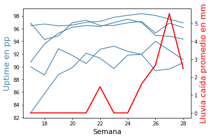

```python
col1 = 'steelblue'
col2 = 'red'

fig,ax = plt.subplots()

ax.plot(ds2.index, ds3.availability, color=col1)

ax.set_xlabel('Semana', fontsize=14)

ax.set_ylabel('Uptime en pp', color=col1, fontsize=16)

ax2 = ax.twinx()

ax2.plot(ds2.index, ds3.data_lluvia, color=col2)

ax2.set_ylabel('Lluvia caída promedio en mm', color=col2, fontsize=16)
```

En este caso, al separar el indicador por zona, vemos que este se ve afectado en diferentes medidas, incluso en algunos períodos presentando indicios de recuperación en períodos de alta lluvia, esto se podría explicar por que la cantidad de lluvia medida no es la misma para todas las zonas y depende del lugar donde se encuentre la estación de medición. Punto aparte, las zonas más periféricas tienden a afectarse mucho más por este tipo de eventos al presentar recurrentemente cortes de energía y problemáticas afines que son de muy baja escala en otras más centrales y urbanizadas.